# 431 Class 15

Thomas E. Love, Ph.D.

2024-10-15

## Today’s Agenda

- Ingesting the Favorite Movies 2024-10-15 data from our Shared Folder in Google Drive
- Creating an Analytic Data Set

### Three Analyses using the Favorite Movies Data

1. Quantitative Outcome and a Quantitative Predictor
2. Quantitative Outcome and a Categorical Predictor
3. Comparing Means of a Quantity with Matched Samples

## Today’s Packages

```r
library(janitor)
library(glue)
library(googlesheets4)
library(infer)
library(patchwork)
library(rstanarm)
library(xfun)
library(easystats)
library(tidyverse)

theme_set(theme_light())

source("c15/data/Love-431.R")
```

## Ingest the `movies_2024-10-15` data

```r
gs4_deauth()

url <- "https://docs.google.com/spreadsheets/d/16fm1693sFjau9sIM-ORamxLL3ZMrBeRSxXqWpP8IBDs/edit?gid=0#gid=0"

mov_raw <- read_sheet(url, na = c("", "NA"))

mov_cleaning <- mov_raw |>
  janitor::clean_names() |>
  mutate(across(where(is.character), as_factor)) |>
  mutate(across(c(mov_id, movie, director, star_1, star_2, star_3, origin,
                  fc_link, rt_link, imdb_cats, synopsis, imdb_id, imdb_link),
                as.character))

dim(mov_cleaning)
```

```
[1] 228  80
```

## Select 35 Variables for Analyses

### 15 Quantitative Variables

```r
v_quant <- c("year", "length", "imdb_ratings", "imdb_stars", "imdb_pct10",
             "metascore", "awards", "budget", "gross_world", "fc_pctwins",
             "rt_critic", "rt_audience", "theaters", "box_2023", "triggers")
```

### 10 Binary Categorical Variables

```r
v_binary <- c("gen_1", "color", "dr_love", "drama", "comedy",
              "st_apple", "st_prime", "st_disney", "st_max", "st_paramount")
```

### 10 Multi-Categorical Variables or Small Counts

```r
v_multi <- c("mpa", "lang_1", "list_24", "bw_rating", "oscars",
             "ebert", "stream_n", "kim_sn", "kim_vg", "kim_lang")
```

## Create `mov_a` with 37 variables

```r
mov_a <- mov_cleaning |> select(mov_id, movie,
                                all_of(v_quant), all_of(v_binary),
                                all_of(v_multi))

dim(mov_a)
```

```
[1] 228  37
```

## Check Variable Types

```r
glimpse(mov_a)
```

```
Rows: 228
Columns: 37
$ mov_id       <chr> "M-001", "M-002", "M-003", "M-004", "M-005", "M-006", "M-…
$ movie        <chr> "3 Idiots", "8 1/2", "10 Things I Hate About You", "2001:…
$ year         <dbl> 2009, 1963, 1999, 1968, 2009, 2013, 1979, 1984, 2009, 201…
$ length       <dbl> 170, 138, 97, 149, 119, 123, 117, 160, 162, 149, 181, 116…
$ imdb_ratings <dbl> 442000, 127000, 397000, 730000, 58000, 396000, 978000, 43…
$ imdb_stars   <dbl> 8.4, 8.0, 7.3, 8.3, 7.9, 7.8, 8.5, 8.4, 7.9, 8.4, 8.4, 8.…
$ imdb_pct10   <dbl> 37.9, 27.0, 15.1, 29.9, 21.9, 17.1, 22.8, 22.5, 21.0, 31.…
$ metascore    <dbl> 67, 93, 70, 84, 87, 55, 89, 87, 83, 68, 78, 87, 57, 80, 4…
$ awards       <dbl> 64, 19, 2, 18, 23, 3, 18, 43, 89, 48, 70, 25, 9, 204, 2, …
$ budget       <dbl> 6632918, NA, 30000000, 12000000, NA, 12000000, 11000000, …
$ gross_world  <dbl> 60262836, 196375, 53479734, 66441232, 879422, 87100449, 1…
$ fc_pctwins   <dbl> 57, 61, 42, 57, 55, 57, 65, 53, 50, 69, 68, 70, 56, 56, 3…
$ rt_critic    <dbl> 100, 98, 71, 92, 99, 70, 98, 89, 81, 85, 94, 93, 63, 88, …
```

[output cut: 24 more lines]

## Quantities

```r
mov_a |> select(year:triggers) |> summary()
```

```
      year          length       imdb_ratings       imdb_stars
 Min.   :1942   Min.   : 70.0   Min.   :    282   Min.   :3.400
 1st Qu.:1996   1st Qu.:103.0   1st Qu.: 158000   1st Qu.:7.100
 Median :2006   Median :117.5   Median : 367000   Median :7.700
 Mean   :2003   Mean   :123.2   Mean   : 555783   Mean   :7.546
 3rd Qu.:2013   3rd Qu.:138.0   3rd Qu.: 783750   3rd Qu.:8.100
 Max.   :2024   Max.   :207.0   Max.   :2900000   Max.   :9.300

   imdb_pct10      metascore          awards           budget
 Min.   : 3.80   Min.   :  9.00   Min.   :  0.00   Min.   :2.00e+05
 1st Qu.:11.57   1st Qu.: 60.25   1st Qu.:  5.00   1st Qu.:1.30e+07
 Median :15.55   Median : 71.00   Median : 16.00   Median :3.00e+07
 Mean   :17.57   Mean   : 70.86   Mean   : 35.62   Mean   :5.91e+07
 3rd Qu.:22.25   3rd Qu.: 83.00   3rd Qu.: 43.25   3rd Qu.:9.00e+07
 Max.   :59.50   Max.   :100.00   Max.   :405.00   Max.   :3.56e+08
                 NA's   :14                        NA's   :22
  gross_world          fc_pctwins      rt_critic       rt_audience
 Min.   :1.546e+03   Min.   :23.00   Min.   : 22.00   Min.   :28.00
 1st Qu.:4.753e+07   1st Qu.:42.00   1st Qu.: 73.00   1st Qu.:76.00
 Median :1.710e+08   Median :52.00   Median : 86.00   Median :86.00
 Mean   :3.321e+08   Mean   :50.73   Mean   : 80.38   Mean   :82.13
 3rd Qu.:4.684e+08   3rd Qu.:59.00   3rd Qu.: 93.00   3rd Qu.:92.00
 Max.   :2.924e+09   Max.   :79.00   Max.   :100.00   Max.   :98.00
 NA's   :8           NA's   :1       NA's   :4        NA's   :1
    theaters       box_2023            triggers
 Min.   :  10   Min.   :2.345e+05   Min.   : 0.00
 1st Qu.:1352   1st Qu.:5.685e+07   1st Qu.:10.00
 Median :2586   Median :1.594e+08   Median :24.00
 Mean   :2437   Mean   :2.494e+08   Mean   :25.96
 3rd Qu.:3517   3rd Qu.:3.283e+08   3rd Qu.:41.00
 Max.   :4662   Max.   :1.730e+09   Max.   :77.00
 NA's   :36     NA's   :31          NA's   :3
```

## Binary Variables

```r
mov_a |> select(gen_1:st_paramount) |> summary()
```

```
 gen_1     color     dr_love       drama            comedy
 M:178   Color:224   No :137   Min.   :0.0000   Min.   :0.0000
 F: 50   BW   :  4   Yes: 91   1st Qu.:0.0000   1st Qu.:0.0000
                               Median :1.0000   Median :0.0000
                               Mean   :0.5789   Mean   :0.4254
                               3rd Qu.:1.0000   3rd Qu.:1.0000
                               Max.   :1.0000   Max.   :1.0000
    st_apple         st_prime        st_disney          st_max
 Min.   :0.0000   Min.   :0.0000   Min.   :0.0000   Min.   :0.0000
 1st Qu.:1.0000   1st Qu.:1.0000   1st Qu.:0.0000   1st Qu.:0.0000
 Median :1.0000   Median :1.0000   Median :0.0000   Median :0.0000
 Mean   :0.8904   Mean   :0.9079   Mean   :0.1579   Mean   :0.1711
 3rd Qu.:1.0000   3rd Qu.:1.0000   3rd Qu.:0.0000   3rd Qu.:0.0000
 Max.   :1.0000   Max.   :1.0000   Max.   :1.0000   Max.   :1.0000
  st_paramount
 Min.   :0.000
 1st Qu.:0.000
 Median :0.000
 Mean   :0.136
 3rd Qu.:0.000
 Max.   :1.000
```

## Multi-Categorical Variables

```r
mov_a |> select(mpa:kim_lang) |> summary()
```

```
      mpa          lang_1       list_24         bw_rating         oscars
 PG-13  :74   English :200   Min.   :0.0000   Min.   :0.000   Min.   : 0.0000
 R      :67   Japanese:  8   1st Qu.:0.0000   1st Qu.:1.000   1st Qu.: 0.0000
 PG     :62   Hindi   :  7   Median :0.0000   Median :3.000   Median : 0.0000
 NR     :13   Italian :  2   Mean   :0.2456   Mean   :2.124   Mean   : 0.9123
 G      : 7   Mandarin:  2   3rd Qu.:0.0000   3rd Qu.:3.000   3rd Qu.: 1.0000
 TV-G   : 2   Persian :  1   Max.   :3.0000   Max.   :3.000   Max.   :11.0000
 (Other): 3   (Other) :  8                    NA's   :10
     ebert          stream_n         kim_sn           kim_vg
 Min.   :1.000   Min.   :0.000   Min.   : 0.000   Min.   : 0.000
 1st Qu.:3.000   1st Qu.:3.000   1st Qu.: 2.000   1st Qu.: 3.000
 Median :3.500   Median :4.000   Median : 3.000   Median : 5.000
 Mean   :3.198   Mean   :3.364   Mean   : 3.293   Mean   : 4.924
 3rd Qu.:4.000   3rd Qu.:4.000   3rd Qu.: 5.000   3rd Qu.: 7.000
 Max.   :4.000   Max.   :5.000   Max.   :10.000   Max.   :10.000
 NA's   :29                      NA's   :71       NA's   :71
    kim_lang
 Min.   : 0.000
 1st Qu.: 3.000
 Median : 4.000
 Mean   : 4.204
 3rd Qu.: 5.000
 Max.   :10.000
 NA's   :71
```

# Analysis 1 (Quantitative Outcome and a Quantitative Predictor)

## Analysis 1

- How strong is the association between `metascore` and `imdb_stars`?

```r
mov_a1 <- mov_a |> filter(complete.cases(metascore, imdb_stars))

mov_a1 |> reframe(lovedist(metascore))
```

```
# A tibble: 1 × 10
      n  miss  mean    sd   med   mad   min   q25   q75   max
  <int> <int> <dbl> <dbl> <dbl> <dbl> <dbl> <dbl> <dbl> <dbl>
1   214     0  70.9  15.7    71  17.8     9  60.2    83   100
```

```r
mov_a1 |> reframe(lovedist(imdb_stars))
```

```
# A tibble: 1 × 10
      n  miss  mean    sd   med   mad   min   q25   q75   max
  <int> <int> <dbl> <dbl> <dbl> <dbl> <dbl> <dbl> <dbl> <dbl>
1   214     0  7.60 0.789   7.7 0.741   3.6   7.1   8.1   9.3
```

## Plot our set of 214 movies

```r
ggplot(mov_a1, aes(x = metascore, y = imdb_stars)) +
  geom_point() +
  geom_smooth(method = "lm", formula = y ~ x, se = TRUE, col = "red") +
  geom_smooth(method = "loess", formula = y ~ x, se = F, col = "blue")
```

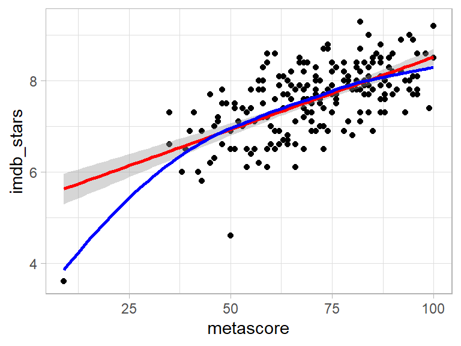

## Which movies are the outliers?

```r
mov_a1 |> filter(imdb_stars < 5) |>
  select(mov_id, movie, imdb_stars, metascore)
```

```
# A tibble: 2 × 4
  mov_id movie              imdb_stars metascore
  <chr>  <chr>                   <dbl>     <dbl>
1 M-130  Madea Goes To Jail        4.6        50
2 M-183  The Room                  3.6         9
```

## What if we ignored these two movies?

```r
mov_a1_new <- mov_a |> filter(imdb_stars > 5, complete.cases(metascore))

mov_a1_new |> reframe(lovedist(metascore))
```

```
# A tibble: 1 × 10
      n  miss  mean    sd   med   mad   min   q25   q75   max
  <int> <int> <dbl> <dbl> <dbl> <dbl> <dbl> <dbl> <dbl> <dbl>
1   212     0  71.2  15.1    71  17.8    35    61  83.2   100
```

```r
mov_a1_new |> reframe(lovedist(imdb_stars))
```

```
# A tibble: 1 × 10
      n  miss  mean    sd   med   mad   min   q25   q75   max
  <int> <int> <dbl> <dbl> <dbl> <dbl> <dbl> <dbl> <dbl> <dbl>
1   212     0  7.63 0.714   7.7 0.741   5.8   7.1   8.1   9.3
```

## Plot our new set of 212 movies

```r
ggplot(mov_a1_new, aes(x = metascore, y = imdb_stars)) +
  geom_point() +
  geom_smooth(method = "lm", formula = y ~ x, se = TRUE, col = "red") +
  geom_smooth(method = "loess", formula = y ~ x, se = F, col = "blue") +
  labs(title = "Positive Association between metascore and star ratings",
       subtitle = glue("Scatterplot of ", nrow(mov_a1_new),
                       " movies with more than 5 stars on IMDB"))
```

## Plot our new set of 212 movies

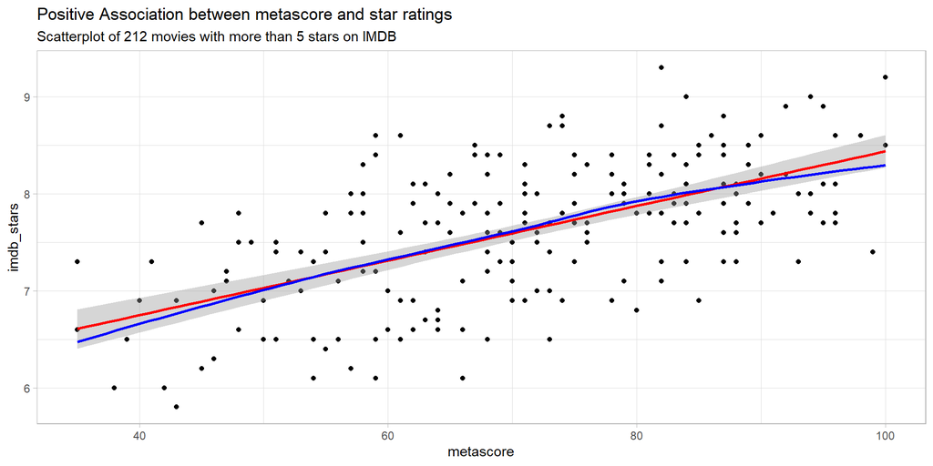

## Fit Model to our 212 Movies

```r
set.seed(20241015)

fit1 <- stan_glm(imdb_stars ~ metascore, data = mov_a1_new, refresh = 0)

model_parameters(fit1)
```

```
Parameter   | Median |       95% CI |   pd |  Rhat |     ESS |                 Prior
------------------------------------------------------------------------------------
(Intercept) |   5.62 | [5.25, 5.99] | 100% | 1.000 | 4032.00 | Normal (7.63 +- 1.78)
metascore   |   0.03 | [0.02, 0.03] | 100% | 1.000 | 4114.00 | Normal (0.00 +- 0.12)
```

```r
model_performance(fit1)
```

```
# Indices of model performance

ELPD     | ELPD_SE |   LOOIC | LOOIC_SE |    WAIC |    R2 | R2 (adj.) |  RMSE | Sigma
-------------------------------------------------------------------------------------
-185.060 |   8.606 | 370.120 |   17.211 | 370.112 | 0.356 |     0.346 | 0.571 | 0.575
```

## Check the model

```r
check_model(fit1)
```

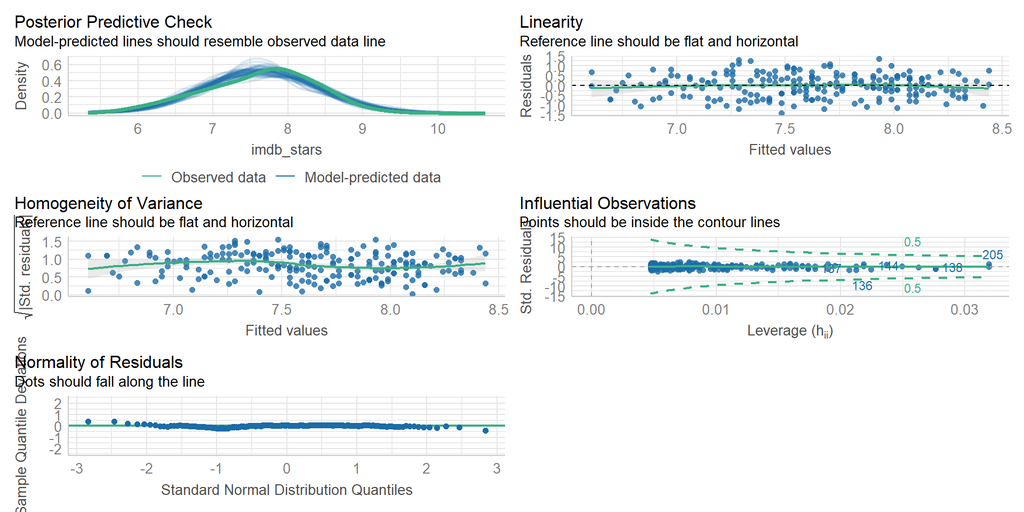

# Analysis 2 (Quantitative Outcome and a Categorical Predictor)

## Analysis 2

- Are higher `fc_pctwins` scores associated with higher levels of `bw_score`?

| Variable | Description |
| --- | --- |
| `fc_pctwins` | % of matchups won on flickchart |
| `bw_rating` | Bechdel-Wallace Test Criteria Met (0-3) |

- `bw_rating` counts these standards: (1) The movie has to have at least two named women in it. (2) Who talk to each other (3) About something besides a man.

## Create ordered factor `bw_score`

Here, we’ll treat the `bw_rating` as a factor.

```r
mov_a2 <- mov_a |>
  filter(complete.cases(fc_pctwins, bw_rating)) |>
  mutate(bw_score = factor(bw_rating))

mov_a2 |> count(bw_score)
```

```
# A tibble: 4 × 2
  bw_score     n
  <fct>    <int>
1 0           18
2 1           61
3 2           15
4 3          124
```

```r
mov_a2 |> reframe(lovedist(fc_pctwins))
```

```
# A tibble: 1 × 10
      n  miss  mean    sd   med   mad   min   q25   q75   max
  <int> <int> <dbl> <dbl> <dbl> <dbl> <dbl> <dbl> <dbl> <dbl>
1   218     0  51.1  12.3    52  13.3    23    42  59.8    79
```

## Plot of these 218 movies

```r
ggplot(mov_a2, aes(x = bw_score, y = fc_pctwins)) +
  geom_violin() +
  geom_boxplot(width = 0.3, notch = TRUE) +
  stat_summary(fun = "mean", geom = "point", size = 2, col = "red")
```

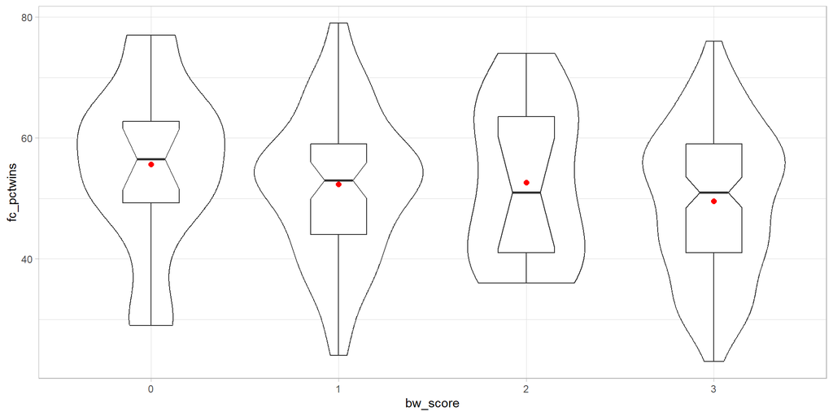

## Fit ANOVA model

```r
fit2 <- lm(fc_pctwins ~ bw_score, data = mov_a2)
anova(fit2)
```

```
Analysis of Variance Table

Response: fc_pctwins
           Df Sum Sq Mean Sq F value Pr(>F)
bw_score    3    778  259.48  1.7186 0.1642
Residuals 214  32311  150.99
```

```r
eta_squared(fit2)
```

```
# Effect Size for ANOVA

Parameter | Eta2 |       95% CI
-------------------------------
bw_score  | 0.02 | [0.00, 1.00]

- One-sided CIs: upper bound fixed at [1.00].
```

## Model `fit2` summaries

```r
model_parameters(fit2)
```

```
Parameter    | Coefficient |   SE |          95% CI | t(214) |      p
---------------------------------------------------------------------
(Intercept)  |       55.61 | 2.90 | [ 49.90, 61.32] |  19.20 | < .001
bw score [1] |       -3.30 | 3.30 | [ -9.80,  3.20] |  -1.00 | 0.318
bw score [2] |       -2.94 | 4.30 | [-11.41,  5.52] |  -0.69 | 0.494
bw score [3] |       -6.03 | 3.10 | [-12.14,  0.08] |  -1.95 | 0.053
```

```r
model_performance(fit2)
```

```
# Indices of model performance

AIC      |     AICc |      BIC |    R2 | R2 (adj.) |   RMSE |  Sigma
--------------------------------------------------------------------
1718.366 | 1718.649 | 1735.289 | 0.024 |     0.010 | 12.174 | 12.288
```

## Pairwise comparisons (Holm method)

```r
estimate_contrasts(fit2, contrast = "bw_score", p_adjust = "Holm")
```

```
Marginal Contrasts Analysis

Level1    |    Level2 | Difference |         95% CI |   SE | t(214) |      p
----------------------------------------------------------------------------
bw_score0 | bw_score1 |       3.30 | [-5.48, 12.08] | 3.30 |   1.00 | > .999
bw_score0 | bw_score2 |       2.94 | [-8.50, 14.38] | 4.30 |   0.69 | > .999
bw_score0 | bw_score3 |       6.03 | [-2.22, 14.28] | 3.10 |   1.95 | 0.318
bw_score1 | bw_score2 |      -0.36 | [-9.79,  9.08] | 3.54 |  -0.10 | > .999
bw_score1 | bw_score3 |       2.73 | [-2.39,  7.85] | 1.92 |   1.42 | 0.784
bw_score2 | bw_score3 |       3.09 | [-5.86, 12.03] | 3.36 |   0.92 | > .999

Marginal contrasts estimated at bw_score
p-value adjustment method: Holm (1979)
```

# Analysis 3 (Comparing Means of a Quantity with Matched Samples)

## Audience Score vs. Critic Score

From Rotten Tomatoes, we have, for almost every movie…

- `rt_audience`: Popcornmeter (audience verified ratings on scale 0-100)
- `rt_critic`: Tomatometer (critic ratings on scale 0-100)

```r
mov_a3 <- filter(mov_a, complete.cases(rt_audience, rt_critic))

mov_a3 |> select(mov_id, movie, rt_audience, rt_critic) |>
  arrange(rt_audience) |> tail(3)
```

```
# A tibble: 3 × 4
  mov_id movie                                         rt_audience rt_critic
  <chr>  <chr>                                               <dbl>     <dbl>
1 M-203  Star Wars: Episode V: The Empire Strikes Back          97        95
2 M-072  The Godfather                                          98        97
3 M-191  The Shawshank Redemption                               98        91
```

## Some Summaries for Analysis 3

```r
mov_a3 |> reframe(lovedist(rt_audience))
```

```
# A tibble: 1 × 10
      n  miss  mean    sd   med   mad   min   q25   q75   max
  <int> <int> <dbl> <dbl> <dbl> <dbl> <dbl> <dbl> <dbl> <dbl>
1   224     0  82.5  12.3    86  10.4    40    76    92    98
```

```r
mov_a3 |> reframe(lovedist(rt_critic))
```

```
# A tibble: 1 × 10
      n  miss  mean    sd   med   mad   min   q25   q75   max
  <int> <int> <dbl> <dbl> <dbl> <dbl> <dbl> <dbl> <dbl> <dbl>
1   224     0  80.4  17.6    86  11.9    22    73    93   100
```

```r
correlation(mov_a3 |> select(rt_audience, rt_critic))
```

```
# Correlation Matrix (pearson-method)

Parameter1  | Parameter2 |    r |       95% CI | t(222) |         p
-------------------------------------------------------------------
rt_audience |  rt_critic | 0.60 | [0.51, 0.68] |  11.26 | < .001***

p-value adjustment method: Holm (1979)
Observations: 224
```

## Paired Differences in Analysis 3

```r
mov_a3 <- mov_a3 |> mutate(acdiff = rt_audience - rt_critic)

mov_a3 |> reframe(lovedist(acdiff))
```

```
# A tibble: 1 × 10
      n  miss  mean    sd   med   mad   min   q25   q75   max
  <int> <int> <dbl> <dbl> <dbl> <dbl> <dbl> <dbl> <dbl> <dbl>
1   224     0  2.09  14.1     0  9.64   -34    -6     7    67
```

```r
ggplot(mov_a3, aes(x = acdiff, y = "n = 224")) +
  geom_violin() + geom_boxplot(width = 0.3) +
  stat_summary(fun = "mean", geom = "point", col = "red", size = 2) +
  labs(y = "")
```

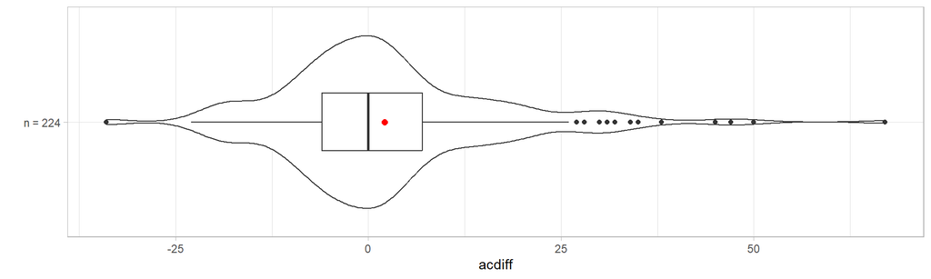

## Some Extreme Differences (A3)

```r
mov_a3_sorted <- mov_a3 |>
  select(mov_id, movie, rt_audience, rt_critic, acdiff) |>
  arrange(desc(acdiff))

mov_a3_sorted |> head(4)
```

```
# A tibble: 4 × 5
  mov_id movie               rt_audience rt_critic acdiff
  <chr>  <chr>                     <dbl>     <dbl>  <dbl>
1 M-130  Madea Goes To Jail           96        29     67
2 M-219  A Walk to Remember           78        28     50
3 M-141  Memoirs of a Geisha          83        36     47
4 M-015  Beaches                      88        43     45
```

```r
mov_a3_sorted |> tail(4)
```

```
# A tibble: 4 × 5
  mov_id movie               rt_audience rt_critic acdiff
  <chr>  <chr>                     <dbl>     <dbl>  <dbl>
1 M-124  The Lobster                  65        87    -22
2 M-197  Sorry To Bother You          70        93    -23
3 M-029  Captain Marvel               45        79    -34
4 M-220  War of the Worlds            42        76    -34
```

## Bootstrap CI

Thanks to the outliers, we’ll use a bootstrap to estimate the mean of the paired (audience - critic) rating differences.

```r
set.seed(20241015)
res3 <- mov_a3 |>
  specify(response = acdiff) |>
  generate(reps = 2000, type = "bootstrap") |>
  calculate(stat = "mean") |>
  get_confidence_interval(level = 0.95, type = "percentile")

res3 |>
  mutate(pt_est = mean(mov_a3$acdiff)) |>
  relocate(pt_est)
```

```
# A tibble: 1 × 3
  pt_est lower_ci upper_ci
   <dbl>    <dbl>    <dbl>
1   2.09    0.335     3.92
```

# That’s it for the slides. Next we’ll do [Breakout Activity 3](https://github.com/THOMASELOVE/431-classes-2024/blob/main/movies/breakout3.md) for the Favorite Movies

[figure not shown]

431 Class 15 | 2024-10-15 | https://thomaselove.github.io/431-2024/